# HW2-EDA with R - Part1: Plotting

### Problem 7 - Basic scatter plots

Create a scatter plot using the Michigan only data frame comparing Income and MeanCommute.

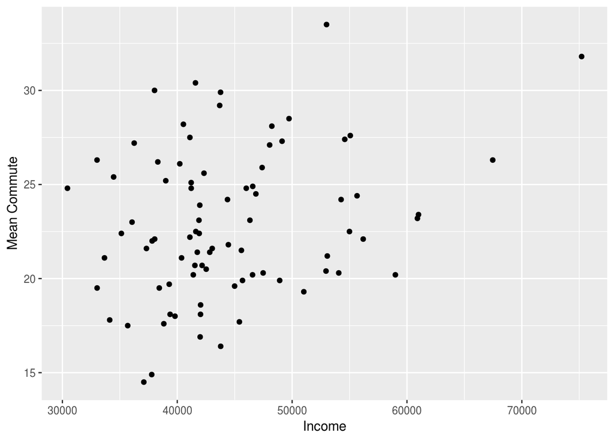

```r
xy_inc_commute <- ggplot(data = county_MI) + geom_point(mapping = aes(x = county_MI$Income, y = county_MI$MeanCommute)) + labs(y= "Mean Commute", x = "Income")

xy_inc_commute
```

Create a modified version of the above scatter plot in which the point color is mapped to peninsula.

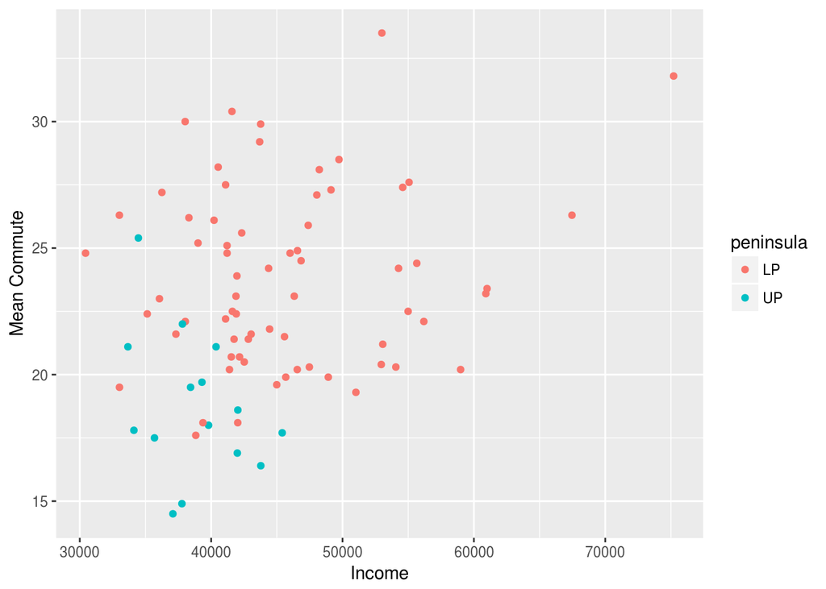

```r
xy_inc_commute_peninsula <- ggplot(data = county_MI, aes(x= county_MI$Income, y = county_MI$MeanCommute, color = peninsula)) + geom_point() + labs(y= "Mean Commute", x = "Income")

xy_inc_commute_peninsula
```

Your thoughts on the relationship between these variables?

The relationship between MeanCommute and Income appears to be positive, as we move from left to right, the value of income increases with respect to the values of MeanCommute. That indicates the general look of the data line is an uphill pattern

Now, create a few more scatter plots using variables of your choosing in which you facet by peninsula as well. How do the relationships compare across the peninsulas?

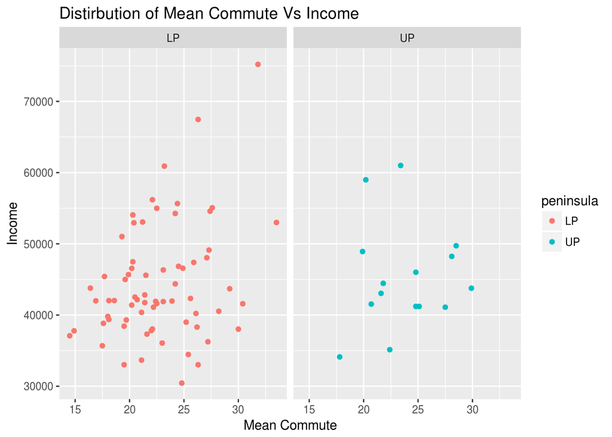

```r
ggplot(data = county_MI, aes(y = county_MI$Income, x = county_MI$MeanCommute, color = peninsula)) + geom_point() + labs(x= "Mean Commute", y = "Income") + facet_wrap(~peninsula) + ggtitle("Distirbution of Mean Commute Vs Income")
```

The relationship between MeanCommute and Income appears to be positive, as we move from left to right, the value of income increases with respect to the values of MeanCommute. That indicates the general look of the data line is an uphill pattern

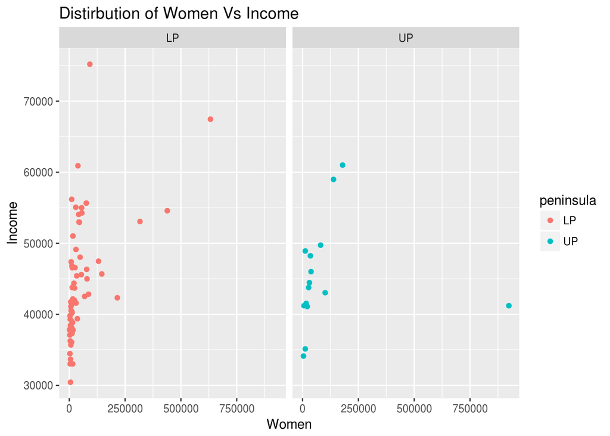

```r
ggplot(data = county_MI, aes(y = county_MI$Income, x = county_MI$Women, color = peninsula)) + geom_point() + labs(x = "Women", y = "Income") + facet_wrap(~peninsula) + ggtitle("Distirbution of Women Vs Income")
```

The relationship between Women and Income appears to be positively correlated. It appears the same for both the peninsulas. The data shows that the linear correlation could be undefined.

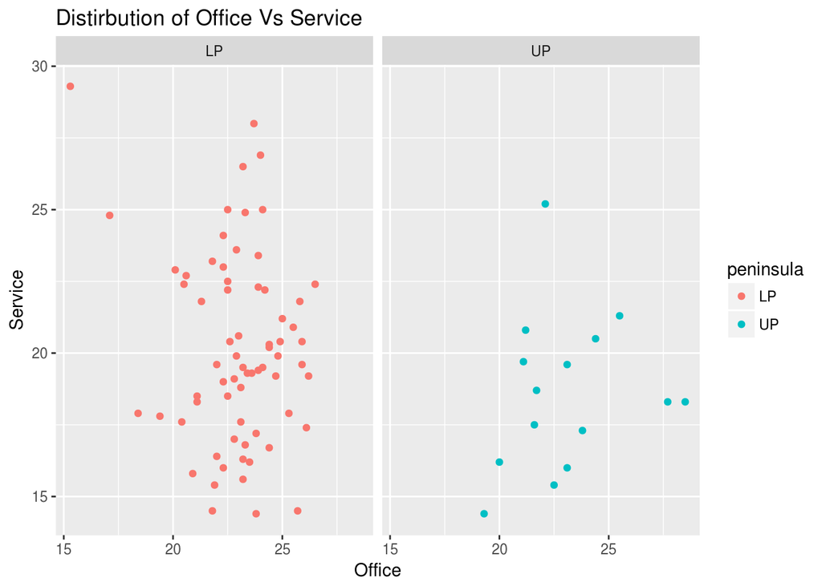

```r
ggplot(data = county_MI, aes(y = county_MI$Service, x = county_MI$Office, color = peninsula)) + geom_point() + labs(x = "Office", y = "Service") + facet_wrap(~peninsula) + ggtitle("Distirbution of Office Vs Service")
```

It appears that the distribution of the point for LP is more scattered between 20-25, indicating there is a low but positive coorelation, whereas, the data for UP is more random.

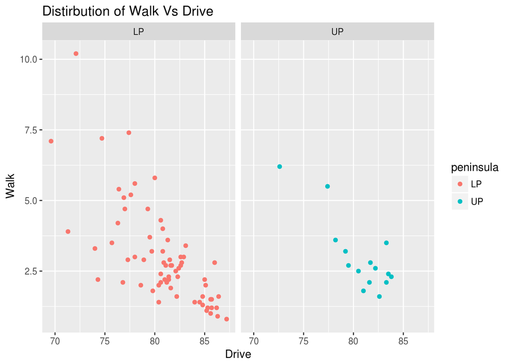

```r
ggplot(data = county_MI, aes(x= county_MI$Drive, y = county_MI$Walk, color = peninsula)) + geom_point() + labs(y= "Walk", x = "Drive") + facet_wrap(~peninsula) + ggtitle("Distirbution of Walk Vs Drive")
```

Now use the full US data frame.

Create a scatter plot of TotalPop by Income.

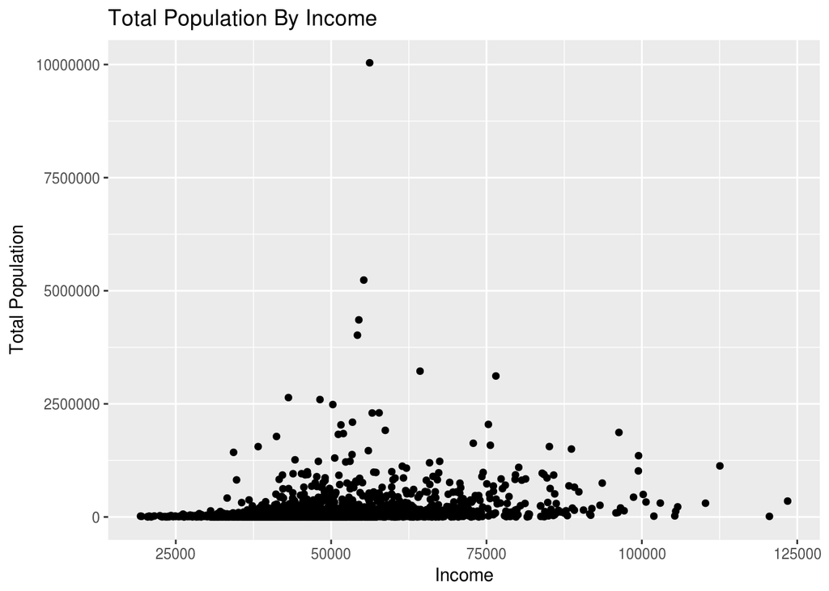

```r
ggplot(county_df) + geom_point(aes(x=county_df$Income, y=county_df$TotalPop)) + ggtitle("Total Population By Income") + xlab("Income") + ylab("Total Population")
```

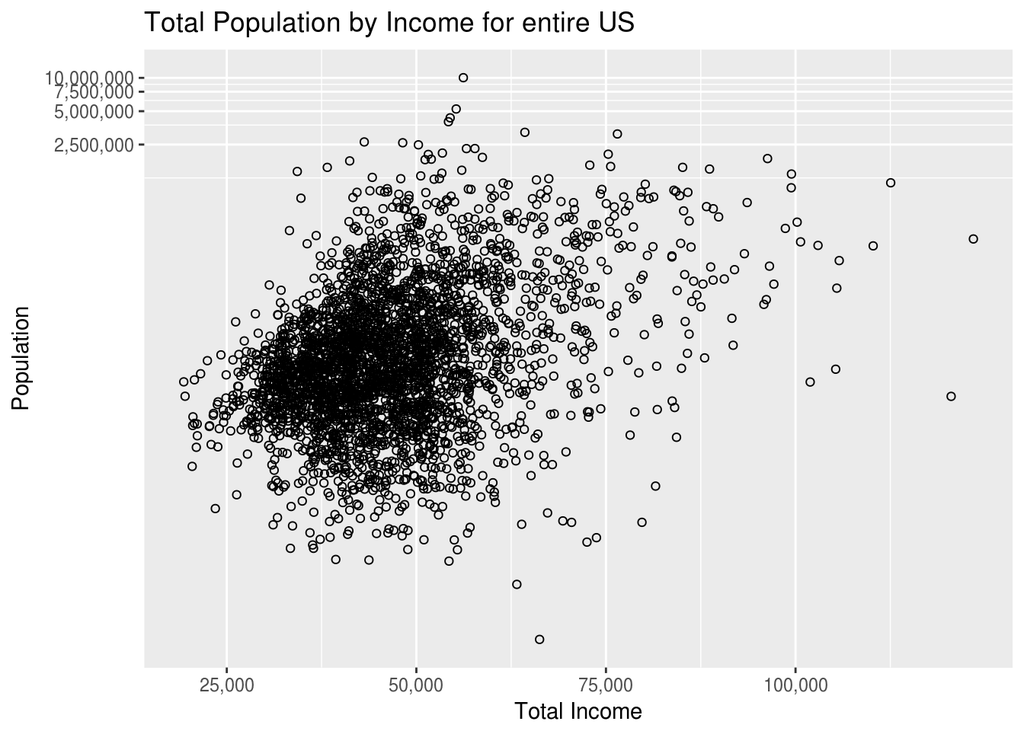

```r
ggplot(county_df, aes(x=county_df$Income, y=county_df$TotalPop))+ xlab("Total Income") +ylab("Population") + geom_point(shape=1) + ggtitle("Total Population by Income for entire US")+scale_y_continuous(labels = scales::comma)+scale_x_continuous(labels = scales::comma) + coord_trans(y = "log10")
```

### Hacker Extra - More analysis

Do some additional plotting to look for interesting patterns or relationships either in the full US dataset or the MI only dataset. In addition, try out some of ggplots additional features such as themes, axis formatting, gridline control, or others.